# DS 624: Homwork 9 (Trees and Rules)

Kuhn: 8.1, 8.2, 8.3, 8.7

Donny Lofland

Source Code: https://github.com/djlofland/DATA624_PredictiveAnalytics/tree/master/Homework_9

## Problem 8.1

Recreate the simulated data from Exercise 7.2:

### Load Data

```r
set.seed(200)
simulated <- mlbench.friedman1(200, sd = 1)
simulated <- cbind(simulated$x, simulated$y)
simulated <- as.data.frame(simulated)
colnames(simulated)[ncol(simulated)] <- "y"
```

### Part (A)

Fit a random forest model to all of the predictors, then estimate the variable importance scores:

```r
set.seed(200)
model1 <- randomForest(y ~ ., data = simulated,
  importance = TRUE,
  ntree = 1000)

(rfImp1 <- varImp(model1, scale = FALSE))
```

```
##         Overall
## V1   8.68879876
## V2   6.47488556
## V3   0.71801185
## V4   7.73791893
## V5   2.28677136
## V6   0.18577159
## V7   0.03371068
## V8  -0.06534861
## V9  -0.10124041
## V10 -0.10053684
```

Did the random forest model significantly use the uninformative predictors (V6 – V10)?

> RandomForest identified `V1`-`V5` as the more important features, but found `V6`-`V10` to not be significantly important.

### Part (B)

Now add an additional predictor that is highly correlated with one of the informative predictors. For example:

```r
set.seed(200)
simulated$duplicate1 <- simulated$V1 + rnorm(200) * .1
cor(simulated$duplicate1, simulated$V1)
```

```
## [1] 0.9497025
```

Fit another random forest model to these data. Did the importance score for V1 change?

```r
set.seed(200)
model2 <- randomForest(y ~ ., data = simulated,
  importance = TRUE,
  ntree = 1000)

(rfImp1 <- varImp(model2, scale = FALSE))
```

```
##                 Overall
## V1          6.106963692
## V2          6.202910805
## V3          0.628919280
## V4          7.019864830
## V5          2.239542012
## V6          0.106378124
## V7         -0.114253349
## V8         -0.090321828
## V9          0.009518246
## V10        -0.036864866
## duplicate1  4.039784189
```

> Yes, the importnce score for `V1` decreased when we added a highly correlated feature `duplicate1`

What happens when you add another predictor that is also highly correlated with V1?

```r
set.seed(200)
simulated$duplicate2 <- simulated$V1 + rnorm(200) * .1
cor(simulated$duplicate1, simulated$V1)
```

```
## [1] 0.9497025
```

```r
set.seed(200)
model3 <- randomForest(y ~ ., data = simulated,
  importance = TRUE,
  ntree = 1000)

(rfImp1 <- varImp(model3, scale = FALSE))
```

```
##                Overall
## V1          5.10087370
## V2          6.43303576
## V3          0.46424167
## V4          7.09328937
## V5          2.07264067
## V6          0.17902427
## V7          0.02434474
## V8         -0.04353591
## V9         -0.04314904
## V10        -0.04931179
## duplicate1  2.93134491
## duplicate2  2.99805957
```

> The importance score for `V1` decreases further when another highly correlated feature `duplicate2` is added.

### Part (C)

Use the `cforest` function in the `party` package to fit a random forest model using conditional inference trees. The `party` package function `varimp` can calculate predictor importance. The `conditional` argument of that function toggles between the traditional importance measure and the modified version described in Strobl et al. (2007). Do these importances show the same pattern as the traditional random forest model?

```r
library(party)

set.seed(200)
model4 <- cforest(y ~ ., data = simulated)

(rfImp2 <- varimp(model4, conditional = FALSE) %>%
    sort(decreasing = T))
```

```
##           V4           V2           V1   duplicate1           V5   duplicate2
##  7.460033551  6.066271874  5.390384642  2.729868197  1.969226339  1.437291092
##           V3           V6           V7           V9          V10           V8
##  0.021937627  0.007088557  0.005249178 -0.006778664 -0.008015955 -0.031046930
```

```r
(rfImp3 <- varimp(model4, conditional = TRUE) %>%
    sort(decreasing = T))
```

```
##           V4           V2           V1           V5   duplicate1   duplicate2
##  6.200117742  4.880955367  2.709403126  1.410084928  1.249186491  0.557887207
##           V6           V3           V7           V9           V8          V10
##  0.019372783  0.010900359  0.010426508  0.005762708  0.001617468 -0.014948188
```

```r
summary(model4)
```

```
##       Length        Class         Mode
##            1 RandomForest           S4
```

### Part (D)

Repeat this process with different tree models, such as boosted trees and Cubist. Does the same pattern occur?

#### Boosted Tree

```r
#gbmModel <- gbm(y ~ ., data = simulated, distribution="gaussian")

gbmGrid <- expand.grid(
  interaction.depth = seq(1, 7, by = 2),
  n.trees = seq(100, 1000, by = 50),
  shrinkage = c(0.01, 0.1),
  n.minobsinnode=10)

metric <- "RMSE"
trainControl <- trainControl(method="cv", number=10)

set.seed(200)

trainX <- simulated %>%
  dplyr::select(-y)

gbmTune <- train(trainX, simulated$y,
  method = "gbm",
  tuneGrid = gbmGrid,
  trControl=trainControl,
  metric=metric,
  bag.fraction=0.75,
  verbose = FALSE)

(gbmImp1 <- varImp(gbmTune, scale = FALSE))
```

```
## gbm variable importance
##
##            Overall
## V4         6372.43
## V2         5077.65
## V1         4551.08
## V5         2205.16
## V3         1989.64
## duplicate1 1169.49
## V6          183.91
## V7          121.26
## V8          103.89
## V10          84.19
## V9           63.97
## duplicate2    0.00
```

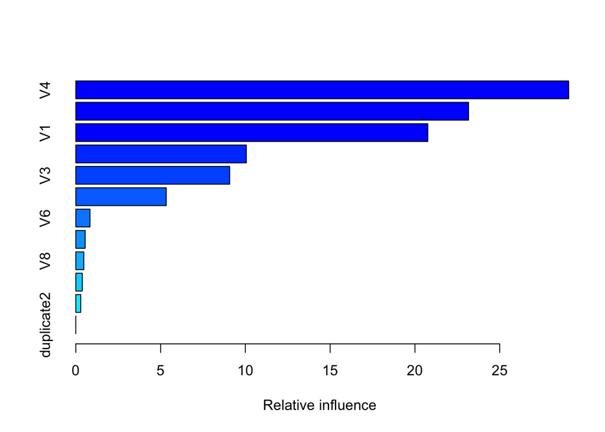

```
##                   var    rel.inf
## V4                 V4 29.0677568
## V2                 V2 23.1616428
## V1                 V1 20.7596935
## V5                 V5 10.0588114
## V3                 V3  9.0757175
## duplicate1 duplicate1  5.3346036
## V6                 V6  0.8389177
## V7                 V7  0.5531361
## V8                 V8  0.4738926
## V10               V10  0.3840461
## V9                 V9  0.2917816
## duplicate2 duplicate2  0.0000000
```

```r
summary(gbmTune)
```

#### Cubist

```r
library(Cubist)

# cubistMod <- cubist(trainX, simulated$y)
cubistMod <- train(trainX, simulated$y, method="cubist")
(cubImp1 <- varImp(cubistMod, scale = FALSE))
```

```
## cubist variable importance
##
##            Overall
## V1            72.0
## V2            57.0
## V4            49.0
## V3            42.0
## V5            37.5
## V6            18.5
## V7             0.0
## duplicate1     0.0
## duplicate2     0.0
## V10            0.0
## V8             0.0
## V9             0.0
```

> Cubist definitely handles feature importance differently than randomForest. With cubist, the order of features switched.

## Problem 8.2

Use a simulation to show tree bias with different granularities.

```r
# Construct a simple dataset with a few features having different frequencies.  Add copies of feature rows
# so some can be excluded from the target and we can create a simple linear model
rows <- list()

for (i in 1:1000) {
  row <- list(i, floor(i/10), floor(i/100), i, floor(i/10), floor(i/100))
  rows <- rbind(rows, row)
}

# Make sure everything is numeric
df <- as_tibble(rows)
df <- transform(df,
                V1=as.numeric(V1),
                V2=as.numeric(V2),
                V3=as.numeric(V3),
                V4=as.numeric(V4),
                V5=as.numeric(V5),
                V6=as.numeric(V6))

# Add a target variable, y, that is a simple linear combiation of V4, V5 and V6
df$y <- (2 * df$V4) + (2 * df$V5) + (2 * df$V6)

# Randomize row order
rows <- sample(nrow(df))
df <- df[rows, ]

# Run RandomForest
set.seed(200)
rfModel <- randomForest(y ~ ., data = df,
  importance = TRUE,
  ntree = 1000)

# Show Feature importance
(dfImp <- varImp(rfModel, scale = FALSE))
```

```
##      Overall
## V1 109427.41
## V2  56568.42
## V3  37698.98
## V4 115976.40
## V5  66579.70
## V6  31540.81
```

> In this simple dataset, `V1`, `V2` and `V3` aren’t included in the linear formula for `y`; however, they are perfectly correlated with `V4`, `V5`, and `V6` so RandomForest incorrectly gives distribites the importance score across the irrelavant features since it cannot tell the difference. Next, the formula for y is a simple linear function, so each variable `V4`, `V5` and `V6` should contribute **equal** weight to `y` and have **equal importance scores**; however, due to bias, RF puts more importance on the features with more distinct values - in this case `V4` has 1000 value while `V5` has 100 value and `V6` only has 10 values.

## Problem 8.3

In stochastic gradient boosting the bagging fraction and learning rate will govern the construction of the trees as they are guided by the gradient. Although the optimal values of these parameters should be obtained through the tuning process, it is helpful to understand how the magnitudes of these parameters affect magnitudes of variable importance. Figure 8.24 provides the variable importance plots for boosting using two extreme values for the bagging fraction (0.1 and 0.9) and the learning rate (0.1 and 0.9) for the solubility data. The left-hand plot has both parameters set to 0.1, and the right-hand plot has both set to 0.9:

### Part (A)

Why does the model on the right focus its importance on just the first few of predictors, whereas the model on the left spreads importance across more predictors?

> The bagged fraction governs how many sample will be used in each step to create a model and learning rate governs the percentage of the new prediction that will be added to the previous pass. The Figure on the right has learning rate = 0.9 and bagged fraction = 0.9. Since the bagged fraction is 0.9, 90% of sample will be drawn which represents most of the total available samples. As such, with each pass, our models will end up being fairly similar and each step will reinforce the previous steps. With a learning rate = 0.9, we are also reinforcing such that the models tend to be similar and inflate the most important features. The figure on the left, with learning rate = 0.1 and bagged fraction = 0.1, will generate tress with more diversity and thus lower down features have a chance to compete for attention - hence more importance given to lower down features.

### Part (B)

Which model do you think would be more predictive of other samples?

> The model on the right (0.9, 0.9) probably doesn’t generalize as well - as mentioned, by having high bagging fraction and learning rate, it hasn’t seen as many combinations of different trees so will overemphasize the few top features. The model on the LEFT (0.1, 0.1) has had a chance to weigh more combinations of different trees providing a better ensemble, lower error, and better generalization. The issue with too low a bagging fraction and/or learning rate is that a model might not have explored enough to learn all the patterns. However, from the text, we know that an ensemble with a bunch of weak learners can perform quite well. I think the LEFT is better, but it’s possible the rates are suboptimally low - we don’t know without some hyperparameter tuning.

### Part (C)

How would increasing interaction depth affect the slope of predictor importance for either model in Fig. 8.24?

> Interaction depth is the number of splits that need to be performed on a tree and increasing this increases the total number of nodes. If interactin depth is too low, we probably have very low accuracy (not enought resolution). As interaction depth increases, above a threshold, we probalky have too many nodes which wouild lead to overfitting and lack of generalization. Increasing interaction depth on the LEFT chart (0.1, 0.1) would probably provide more resolution, but with such a small learning rate, it might be counter productive. For the model on the RIGHT (0.9, 0.9), I would suspect increasing tree depth might actually hurt performance.

## Problem 8.7

Refer to Exercises 6.3 and 7.5 which describe a chemical manufacturing process. Use the same data imputation, data splitting, and pre-processing steps as before and train several tree-based models:

### Load & Clean Data

```r
# NOTE: Code copied from my Homework #7
data("ChemicalManufacturingProcess")

cmp <- as_tibble(ChemicalManufacturingProcess)

x_raw <- cmp[,2:58]
y_raw <- as.matrix(cmp$Yield)

print(paste(nrow(x_raw), ncol(x_raw)))
```

```
## [1] "176 57"
```

```r
print(paste(nrow(y_raw), ncol(y_raw)))
```

```
## [1] "176 1"
```

```r
# Various NA plots to inspect data
knitr::kable(miss_var_summary(cmp) %>% filter(n_miss > 0),
             caption = 'Missing Values',
             format="html",
             table.attr="style='width:50%;'") %>%
  kableExtra::kable_styling()
```

Missing Values

| variable | n_miss | pct_miss |
| --- | --- | --- |
| ManufacturingProcess03 | 15 | 8.5227273 |
| ManufacturingProcess11 | 10 | 5.6818182 |
| ManufacturingProcess10 | 9 | 5.1136364 |
| ManufacturingProcess25 | 5 | 2.8409091 |
| ManufacturingProcess26 | 5 | 2.8409091 |
| ManufacturingProcess27 | 5 | 2.8409091 |
| ManufacturingProcess28 | 5 | 2.8409091 |
| ManufacturingProcess29 | 5 | 2.8409091 |
| ManufacturingProcess30 | 5 | 2.8409091 |
| ManufacturingProcess31 | 5 | 2.8409091 |
| ManufacturingProcess33 | 5 | 2.8409091 |
| ManufacturingProcess34 | 5 | 2.8409091 |
| ManufacturingProcess35 | 5 | 2.8409091 |
| ManufacturingProcess36 | 5 | 2.8409091 |
| ManufacturingProcess02 | 3 | 1.7045455 |
| ManufacturingProcess06 | 2 | 1.1363636 |
| ManufacturingProcess01 | 1 | 0.5681818 |
| ManufacturingProcess04 | 1 | 0.5681818 |
| ManufacturingProcess05 | 1 | 0.5681818 |
| ManufacturingProcess07 | 1 | 0.5681818 |
| ManufacturingProcess08 | 1 | 0.5681818 |
| ManufacturingProcess12 | 1 | 0.5681818 |
| ManufacturingProcess14 | 1 | 0.5681818 |
| ManufacturingProcess22 | 1 | 0.5681818 |
| ManufacturingProcess23 | 1 | 0.5681818 |
| ManufacturingProcess24 | 1 | 0.5681818 |
| ManufacturingProcess40 | 1 | 0.5681818 |
| ManufacturingProcess41 | 1 | 0.5681818 |

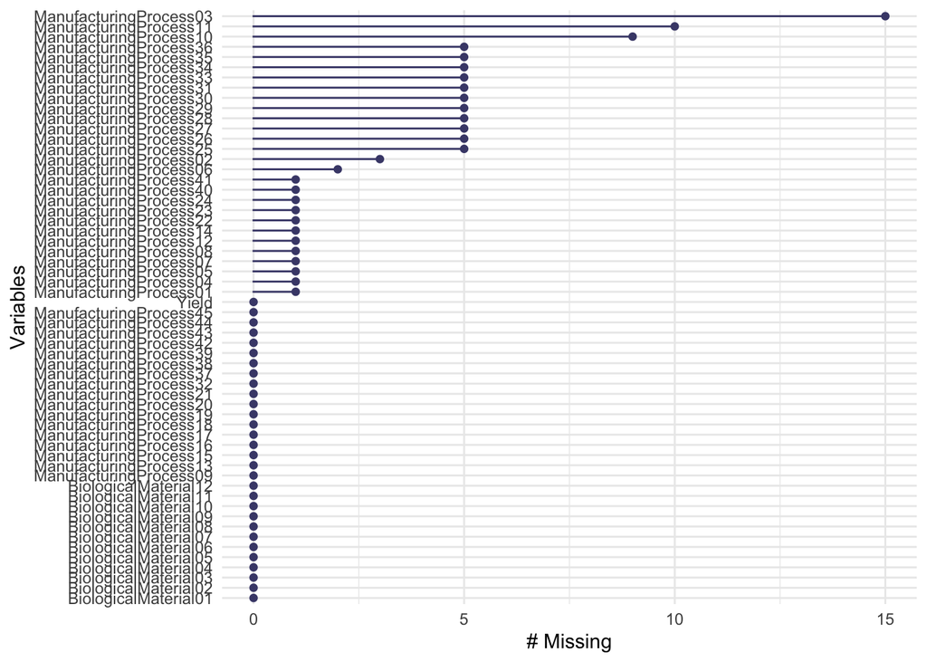

```r
gg_miss_var(cmp)
```

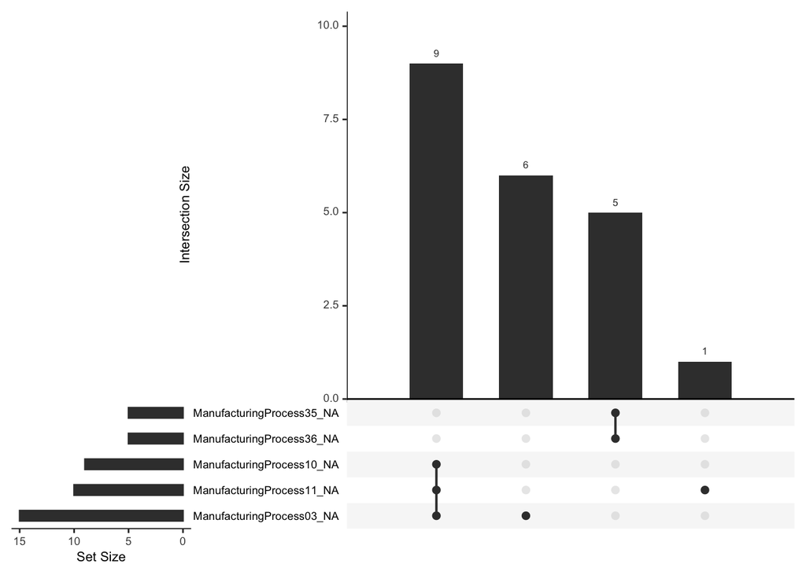

```r
gg_miss_upset(cmp)
```

```r
# Impute missing using KNN
x_imputed <- knn.impute(as.matrix(x_raw), k=10)

# Check for columns with little variance - candidate to drop
lowVariance <- nearZeroVar(x_imputed, names = TRUE)
head(lowVariance)
```

```
## [1] "BiologicalMaterial07"
```

```r
lowVariance <- nearZeroVar(x_imputed)

x_lowvar <- x_imputed[,-lowVariance]

# Deal with outliers ... impute to median
x_outliers <- outlieR::impute(x_lowvar, fill='median')

# Find and drop high correlation features
correlations <- cor(x_outliers)
highCorr <- findCorrelation(correlations, names=TRUE, cutoff=0.9)
(highCorr)
```

```
## [1] "BiologicalMaterial02"   "ManufacturingProcess26" "BiologicalMaterial04"
## [4] "BiologicalMaterial12"   "ManufacturingProcess11" "ManufacturingProcess27"
## [7] "ManufacturingProcess44" "ManufacturingProcess40"
```

```r
highCorr <- findCorrelation(correlations, cutoff=0.9)
x_corr <- x_outliers[,-highCorr]

# Transofrm our dat (scale, center, boxcox)
x_transf <-  preProcess(x_corr, method=c('center', 'scale', 'BoxCox'))
x_transf <- predict(x_transf, x_corr)
```

### Split Training & Testing

```r
# get training/test split
trainingRows <- createDataPartition(y_raw, p=0.8, list=FALSE)

# Build training datasets
trainX <- x_transf[trainingRows,]
trainY <- y_raw[trainingRows]

# put remaining rows into the test sets
testX <- x_transf[-trainingRows,]
testY <- y_raw[-trainingRows]

# Build a DF
trainingData <- as.data.frame(trainX)
trainingData$Yield <- trainY
```

### Part (A)

Which tree-based regression model gives the optimal resampling and test set performance?

#### RandomForest

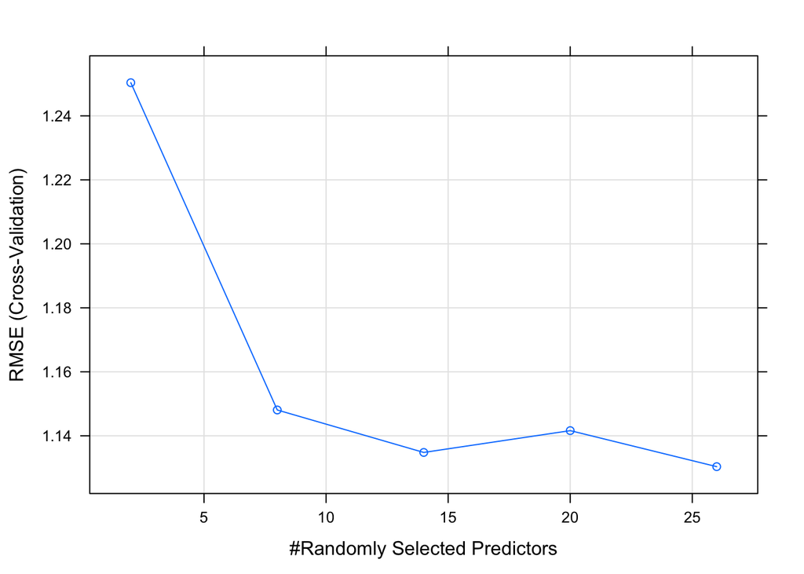

```r
set.seed(42424)

cl <- makePSOCKcluster(5)
registerDoParallel(cl)

## Create a specific candidate set of models to evaluate:
rfGrid <- expand.grid(
  .mtry = c(2, 8, 14, 20, 26)
)

ctrl <- trainControl(method='cv', number=10)

rfTune <- train(trainX, trainY,
  method = "rf",
  tuneGrid = rfGrid,
  trControl = ctrl)

stopCluster(cl)

# Model results
plot(rfTune)
```

```r
summary(rfTune)
```

```
##                 Length Class      Mode
## call              4    -none-     call
## type              1    -none-     character
## predicted       144    -none-     numeric
## mse             500    -none-     numeric
## rsq             500    -none-     numeric
## oob.times       144    -none-     numeric
## importance       48    -none-     numeric
## importanceSD      0    -none-     NULL
## localImportance   0    -none-     NULL
## proximity         0    -none-     NULL
## ntree             1    -none-     numeric
## mtry              1    -none-     numeric
## forest           11    -none-     list
## coefs             0    -none-     NULL
## y               144    -none-     numeric
## test              0    -none-     NULL
## inbag             0    -none-     NULL
## xNames           48    -none-     character
## problemType       1    -none-     character
## tuneValue         1    data.frame list
## obsLevels         1    -none-     logical
## param             0    -none-     list
```

```r
varImp(rfTune)
```

```
## rf variable importance
##
##   only 20 most important variables shown (out of 48)
##
##                        Overall
## ManufacturingProcess32 100.000
## ManufacturingProcess13  22.699
## BiologicalMaterial06    17.613
## ManufacturingProcess36  13.810
## ManufacturingProcess06  13.066
## BiologicalMaterial03    12.956
## ManufacturingProcess17  12.704
## BiologicalMaterial11    10.211
## ManufacturingProcess09   9.384
## ManufacturingProcess31   8.052
## BiologicalMaterial01     7.057
## ManufacturingProcess15   4.963
## ManufacturingProcess28   4.756
## BiologicalMaterial08     4.597
## ManufacturingProcess21   4.181
## ManufacturingProcess30   3.816
## BiologicalMaterial09     3.782
## ManufacturingProcess39   3.420
## ManufacturingProcess24   3.321
## BiologicalMaterial10     3.141
```

```r
modelPred <- predict(rfTune, newdata=testX)

modelValues <- data.frame(obs = testY, pred=modelPred)
colnames(modelValues) = c('obs', 'pred')
(rf_values <- defaultSummary(modelValues))
```

```
##     RMSE Rsquared      MAE
## 1.314611 0.564701 1.011440
```

#### GBM

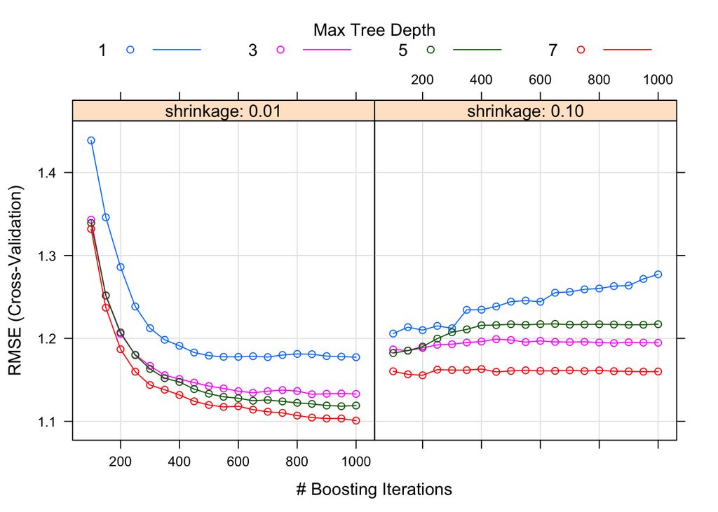

```r
set.seed(42424)

cl <- makePSOCKcluster(5)
registerDoParallel(cl)

## Create a specific candidate set of models to evaluate:
gbmGrid <- expand.grid(
  .interaction.depth = seq(1, 7, by = 2),
  .n.trees = seq(100, 1000, by = 50),
  .shrinkage = c(0.01, 0.1),
  .n.minobsinnode = 10
  )

ctrl <- trainControl(method='cv', number=10)

gbmTune <- train(trainX, trainY,
  method = "gbm",
  tuneGrid = gbmGrid,
  trControl = ctrl,
  verbose = FALSE)

stopCluster(cl)

# Model results
plot(gbmTune)
```

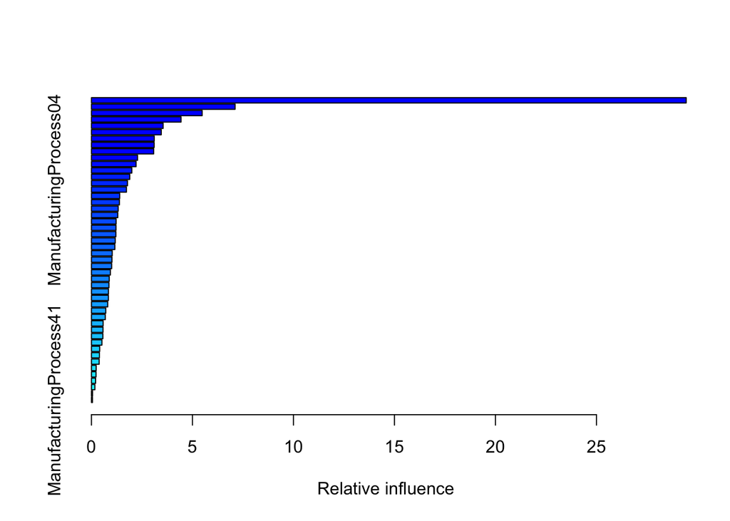

```
##                                           var     rel.inf
## ManufacturingProcess32 ManufacturingProcess32 29.44156537
## ManufacturingProcess13 ManufacturingProcess13  7.10962837
## ManufacturingProcess06 ManufacturingProcess06  5.48061730
## ManufacturingProcess17 ManufacturingProcess17  4.43533004
## BiologicalMaterial03     BiologicalMaterial03  3.54816389
## ManufacturingProcess09 ManufacturingProcess09  3.45464118
## ManufacturingProcess31 ManufacturingProcess31  3.10847311
## BiologicalMaterial06     BiologicalMaterial06  3.10328460
## ManufacturingProcess15 ManufacturingProcess15  3.07907842
## BiologicalMaterial11     BiologicalMaterial11  2.28273768
## BiologicalMaterial05     BiologicalMaterial05  2.20832881
## ManufacturingProcess36 ManufacturingProcess36  1.99751960
## ManufacturingProcess43 ManufacturingProcess43  1.89438624
## BiologicalMaterial09     BiologicalMaterial09  1.78256058
## ManufacturingProcess04 ManufacturingProcess04  1.73064022
## ManufacturingProcess05 ManufacturingProcess05  1.39865204
## ManufacturingProcess39 ManufacturingProcess39  1.38342492
## ManufacturingProcess18 ManufacturingProcess18  1.32249263
## ManufacturingProcess24 ManufacturingProcess24  1.30287458
## ManufacturingProcess20 ManufacturingProcess20  1.21963965
## BiologicalMaterial10     BiologicalMaterial10  1.21423432
## ManufacturingProcess30 ManufacturingProcess30  1.20948735
## ManufacturingProcess37 ManufacturingProcess37  1.17816723
## BiologicalMaterial01     BiologicalMaterial01  1.15879398
## BiologicalMaterial08     BiologicalMaterial08  1.02741630
## ManufacturingProcess21 ManufacturingProcess21  1.01617238
## ManufacturingProcess14 ManufacturingProcess14  1.00027002
## ManufacturingProcess01 ManufacturingProcess01  0.93775555
## ManufacturingProcess29 ManufacturingProcess29  0.88099138
## ManufacturingProcess45 ManufacturingProcess45  0.86580877
## ManufacturingProcess03 ManufacturingProcess03  0.84129183
## ManufacturingProcess16 ManufacturingProcess16  0.83916408
## ManufacturingProcess35 ManufacturingProcess35  0.80562454
## ManufacturingProcess19 ManufacturingProcess19  0.70792312
## ManufacturingProcess22 ManufacturingProcess22  0.68366881
## ManufacturingProcess25 ManufacturingProcess25  0.57619991
## ManufacturingProcess02 ManufacturingProcess02  0.57083886
## ManufacturingProcess23 ManufacturingProcess23  0.56506750
## ManufacturingProcess42 ManufacturingProcess42  0.51801931
## ManufacturingProcess28 ManufacturingProcess28  0.40754508
## ManufacturingProcess10 ManufacturingProcess10  0.39489666
## ManufacturingProcess33 ManufacturingProcess33  0.38088533
## ManufacturingProcess08 ManufacturingProcess08  0.23261377
## ManufacturingProcess07 ManufacturingProcess07  0.22501714
## ManufacturingProcess12 ManufacturingProcess12  0.20423852
## ManufacturingProcess38 ManufacturingProcess38  0.16941287
## ManufacturingProcess34 ManufacturingProcess34  0.05398256
## ManufacturingProcess41 ManufacturingProcess41  0.05047359
```

```r
summary(gbmTune)
```

```r
varImp(gbmTune)
```

```
## gbm variable importance
##
##   only 20 most important variables shown (out of 48)
##
##                        Overall
## ManufacturingProcess32 100.000
## ManufacturingProcess13  24.018
## ManufacturingProcess06  18.475
## ManufacturingProcess17  14.919
## BiologicalMaterial03    11.901
## ManufacturingProcess09  11.582
## ManufacturingProcess31  10.405
## BiologicalMaterial06    10.387
## ManufacturingProcess15  10.304
## BiologicalMaterial11     7.595
## BiologicalMaterial05     7.342
## ManufacturingProcess36   6.625
## ManufacturingProcess43   6.274
## BiologicalMaterial09     5.893
## ManufacturingProcess04   5.717
## ManufacturingProcess05   4.587
## ManufacturingProcess39   4.535
## ManufacturingProcess18   4.328
## ManufacturingProcess24   4.261
## ManufacturingProcess20   3.978
```

```r
modelPred <- predict(gbmTune, newdata=testX)

modelValues <- data.frame(obs = testY, pred=modelPred)
colnames(modelValues) = c('obs', 'pred')
(gbm_values <- defaultSummary(modelValues))
```

```
##      RMSE  Rsquared       MAE
## 1.2592608 0.5920278 0.9807692
```

#### Cubist

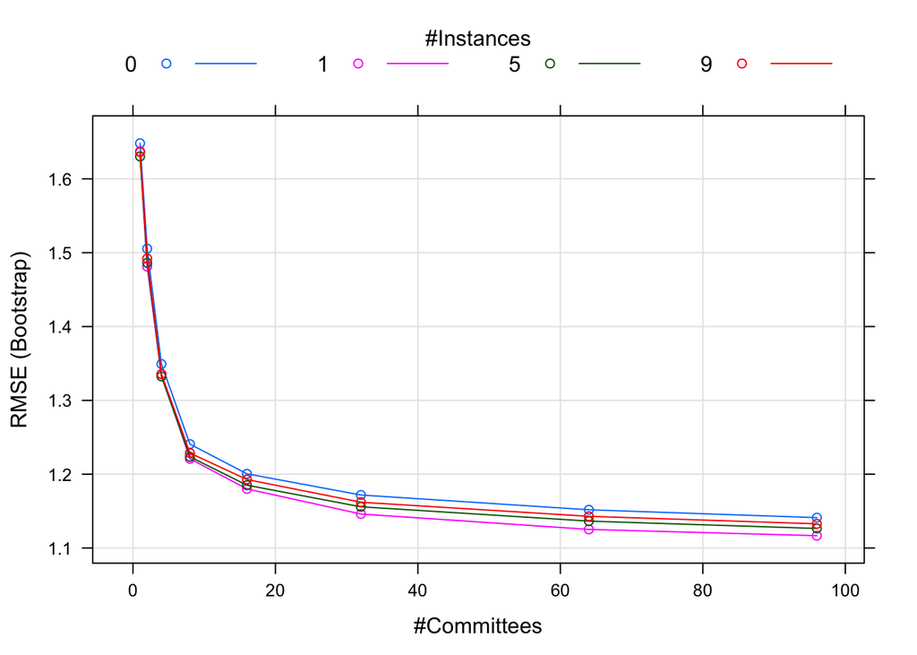

```r
set.seed(42424)

cl <- makePSOCKcluster(5)
registerDoParallel(cl)

## Create a specific candidate set of models to evaluate:
cubGrid <- expand.grid(
  .committees = c(1, 2, 4, 8, 16, 32, 64, 96),
  .neighbors = c(0, 1, 5, 9)
  )

ctrl <- trainControl(method='cv', number=10)

cubTune <- train(trainX, trainY,
  method = "cubist",
  tuneGrid = cubGrid)

stopCluster(cl)

# Model results
plot(cubTune)
```

```r
summary(cubTune)
```

```
##
## Call:
## cubist.default(x = x, y = y, committees = param$committees)
##
##
## Cubist [Release 2.07 GPL Edition]  Wed Dec  2 22:06:05 2020
## ---------------------------------
##
##     Target attribute `outcome'
##
## Read 144 cases (49 attributes) from undefined.data
##
## Model 1:
##
##   Rule 1/1: [43 cases, mean 38.560, range 36.77 to 41.43, est err 0.583]
##
##     if
##  BiologicalMaterial06 <= -0.4236438
##  ManufacturingProcess32 <= -0.04259344
##     then
##  outcome = 40.374 - 6.66 ManufacturingProcess39
##            + 1.25 ManufacturingProcess42 - 0.78 ManufacturingProcess13
##            + 0.51 ManufacturingProcess06 + 0.34 ManufacturingProcess32
##            - 0.22 ManufacturingProcess33 + 0.15 ManufacturingProcess15
##            - 0.05 ManufacturingProcess35
##
##   Rule 1/2: [38 cases, mean 39.806, range 38.2 to 42.07, est err 0.545]
##
##     if
##  BiologicalMaterial06 > -0.4236438
##  ManufacturingProcess32 <= -0.04259344
##     then
##  outcome = 40.144 + 0.59 ManufacturingProcess04
##            + 0.54 ManufacturingProcess32 - 0.57 ManufacturingProcess17
##            - 0.38 ManufacturingProcess31 + 0.25 ManufacturingProcess29
##            - 0.24 ManufacturingProcess33 - 0.12 ManufacturingProcess20
##            - 0.04 ManufacturingProcess13 + 0.02 ManufacturingProcess15
##
##   Rule 1/3: [23 cases, mean 41.004, range 36.83 to 43.88, est err 0.784]
##
```

[output cut: 2052 more lines]

```
##             8%    ManufacturingProcess19
##             8%    ManufacturingProcess10
##             7%    ManufacturingProcess20
##             5%    ManufacturingProcess24
##             5%    ManufacturingProcess28
##             5%    ManufacturingProcess18
##             4%    ManufacturingProcess35
##             3%    ManufacturingProcess05
##             3%    BiologicalMaterial01
##             3%    ManufacturingProcess37
##             2%    ManufacturingProcess03
##             2%    ManufacturingProcess12
##
##
## Time: 0.3 secs
```

```r
varImp(cubTune)
```

```
## cubist variable importance
##
##   only 20 most important variables shown (out of 48)
##
##                        Overall
## ManufacturingProcess32  100.00
## ManufacturingProcess13   43.81
## ManufacturingProcess17   39.05
## ManufacturingProcess04   39.05
## ManufacturingProcess33   38.10
## ManufacturingProcess29   33.33
## BiologicalMaterial06     32.38
## ManufacturingProcess15   28.57
## ManufacturingProcess36   19.05
## ManufacturingProcess09   19.05
## BiologicalMaterial03     19.05
## ManufacturingProcess39   18.10
## ManufacturingProcess31   16.19
## BiologicalMaterial11     15.24
## ManufacturingProcess21   15.24
## ManufacturingProcess30   15.24
## ManufacturingProcess16   14.29
## ManufacturingProcess14   11.43
## BiologicalMaterial10     11.43
## ManufacturingProcess06   10.48
```

```r
modelPred <- predict(cubTune, newdata=testX)

modelValues <- data.frame(obs = testY, pred=modelPred)
colnames(modelValues) = c('obs', 'pred')
(cub_values <- defaultSummary(modelValues))
```

```
##      RMSE  Rsquared       MAE
## 0.7674541 0.8651562 0.6235312
```

#### Summary

```r
(models_summary <- rbind(rf_values, gbm_values, cub_values))
```

```
##                 RMSE  Rsquared       MAE
## rf_values  1.3146113 0.5647010 1.0114398
## gbm_values 1.2592608 0.5920278 0.9807692
## cub_values 0.7674541 0.8651562 0.6235312
```

### Part (B)

Which predictors are most important in the optimal tree-based regression model? Do either the biological or process variables dominate the list? How do the top 10 important predictors compare to the top 10 predictors from the optimal linear and nonlinear models?

### Part (C)

Plot the optimal single tree with the distribution of yield in the terminal nodes. Does this view of the data provide additional knowledge about the biological or process predictors and their relationship with yield?

> Note that Cubist was my winner which doesn’t lend it’s to printing a “tree” with terminal nodes. After a bunch of fails, I gave up trying to print a pretty decision tree for my GBM model. Instead, I’m going to train a simple CART model using rpart2 since I do know how to print a nice decision tree from that model.

```r
library(rpart)
library(rpart.plot)
library(partykit)
library(party)
library(rattle)
set.seed(42424)

cl <- makePSOCKcluster(5)
registerDoParallel(cl)

rpartControl <- trainControl(
  method= "cv",
  number=10
)

model <- train(trainX, trainY,
              method="rpart2",
              trControl = rpartControl,
              tuneLength=10)

stopCluster(cl)

(model)
```

```
## CART
##
## 144 samples
##  48 predictor
##
## No pre-processing
## Resampling: Cross-Validated (10 fold)
## Summary of sample sizes: 128, 130, 130, 131, 129, 129, ...
## Resampling results across tuning parameters:
##
##   maxdepth  RMSE      Rsquared   MAE
##    1        1.420425  0.4139289  1.148394
##    2        1.432901  0.4105528  1.139213
##    3        1.401456  0.4503310  1.084805
##    4        1.433047  0.4414313  1.092505
##    5        1.443769  0.4476999  1.115953
##    6        1.416983  0.4663819  1.101035
##    7        1.461927  0.4258692  1.138774
##    8        1.443897  0.4303523  1.123700
##    9        1.429911  0.4310018  1.107420
##   10        1.423474  0.4387595  1.107968
##
## RMSE was used to select the optimal model using the smallest value.
## The final value used for the model was maxdepth = 3.
```

[figure not shown]

```r
fancyRpartPlot(model$finalModel,palettes="RdPu")
```